# Practical Machine Learning: Prediction Assignment

Jochen van Waasen

2022-09-015

## 1. Overview

In this project, we use data from accelerometers on the belt, forearm, arm, and dumbell of 6 participants.

One thing that people regularly do is quantify how much of a particular activity they do, but they rarely quantify how well they do it. The participants were asked to perform barbell lifts correctly and incorrectly in 5 different ways.

The goal is to predict how well the six participants practiced their exercises.

## 2. Loading and preparing the data

```r
dt_training <- read.csv(url("https://d396qusza40orc.cloudfront.net/predmachlearn/pml-training.csv"), strip.white = TRUE)
```

Quick data overview:

```r
dim(dt_training)
```

```
## [1] 19622   160
```

```r
head(dt_training)
```

```
##   X user_name raw_timestamp_part_1 raw_timestamp_part_2   cvtd_timestamp
## 1 1  carlitos           1323084231               788290 05/12/2011 11:23
## 2 2  carlitos           1323084231               808298 05/12/2011 11:23
## 3 3  carlitos           1323084231               820366 05/12/2011 11:23
## 4 4  carlitos           1323084232               120339 05/12/2011 11:23
## 5 5  carlitos           1323084232               196328 05/12/2011 11:23
## 6 6  carlitos           1323084232               304277 05/12/2011 11:23
##   new_window num_window roll_belt pitch_belt yaw_belt total_accel_belt
## 1         no         11      1.41       8.07    -94.4                3
## 2         no         11      1.41       8.07    -94.4                3
## 3         no         11      1.42       8.07    -94.4                3
## 4         no         12      1.48       8.05    -94.4                3
## 5         no         12      1.48       8.07    -94.4                3
## 6         no         12      1.45       8.06    -94.4                3
##   kurtosis_roll_belt kurtosis_picth_belt kurtosis_yaw_belt skewness_roll_belt
```

[output cut: 251 more lines]

Data quality (identify columns with high percentage of NA data values):

```r
colMeans(is.na(dt_training))
```

```
##                        X                user_name     raw_timestamp_part_1
##                0.0000000                0.0000000                0.0000000
##     raw_timestamp_part_2           cvtd_timestamp               new_window
##                0.0000000                0.0000000                0.0000000
##               num_window                roll_belt               pitch_belt
##                0.0000000                0.0000000                0.0000000
##                 yaw_belt         total_accel_belt       kurtosis_roll_belt
##                0.0000000                0.0000000                0.0000000
##      kurtosis_picth_belt        kurtosis_yaw_belt       skewness_roll_belt
##                0.0000000                0.0000000                0.0000000
##     skewness_roll_belt.1        skewness_yaw_belt            max_roll_belt
##                0.0000000                0.0000000                0.9793089
##           max_picth_belt             max_yaw_belt            min_roll_belt
##                0.9793089                0.0000000                0.9793089
##           min_pitch_belt             min_yaw_belt      amplitude_roll_belt
##                0.9793089                0.0000000                0.9793089
##     amplitude_pitch_belt       amplitude_yaw_belt     var_total_accel_belt
##                0.9793089                0.0000000                0.9793089
##            avg_roll_belt         stddev_roll_belt            var_roll_belt
##                0.9793089                0.9793089                0.9793089
##           avg_pitch_belt        stddev_pitch_belt           var_pitch_belt
##                0.9793089                0.9793089                0.9793089
##             avg_yaw_belt          stddev_yaw_belt             var_yaw_belt
##                0.9793089                0.9793089                0.9793089
##             gyros_belt_x             gyros_belt_y             gyros_belt_z
##                0.0000000                0.0000000                0.0000000
##             accel_belt_x             accel_belt_y             accel_belt_z
##                0.0000000                0.0000000                0.0000000
##            magnet_belt_x            magnet_belt_y            magnet_belt_z
##                0.0000000                0.0000000                0.0000000
##                 roll_arm                pitch_arm                  yaw_arm
##                0.0000000                0.0000000                0.0000000
##          total_accel_arm            var_accel_arm             avg_roll_arm
##                0.0000000                0.9793089                0.9793089
##          stddev_roll_arm             var_roll_arm            avg_pitch_arm
##                0.9793089                0.9793089                0.9793089
##         stddev_pitch_arm            var_pitch_arm              avg_yaw_arm
##                0.9793089                0.9793089                0.9793089
##           stddev_yaw_arm              var_yaw_arm              gyros_arm_x
##                0.9793089                0.9793089                0.0000000
```

[output cut: 53 more lines]

```
##                0.0000000                0.0000000                0.9793089
##         avg_roll_forearm      stddev_roll_forearm         var_roll_forearm
##                0.9793089                0.9793089                0.9793089
##        avg_pitch_forearm     stddev_pitch_forearm        var_pitch_forearm
##                0.9793089                0.9793089                0.9793089
##          avg_yaw_forearm       stddev_yaw_forearm          var_yaw_forearm
##                0.9793089                0.9793089                0.9793089
##          gyros_forearm_x          gyros_forearm_y          gyros_forearm_z
##                0.0000000                0.0000000                0.0000000
##          accel_forearm_x          accel_forearm_y          accel_forearm_z
##                0.0000000                0.0000000                0.0000000
##         magnet_forearm_x         magnet_forearm_y         magnet_forearm_z
##                0.0000000                0.0000000                0.0000000
##                   classe
##                0.0000000
```

If a column contains NA values it seems almost all the data in that column is not usable: > 97% NA per column. These column do not add value as the amount of data provided is too small.

Data cleaning: remove columns with > 97% NA

```r
dt_training = dt_training[,!sapply(dt_training, function(x) mean(is.na(x)))>0.97]
```

The quick data overview showed a lot of columns with empty entries also. Replace all empty values with NA and identify the percentage of empty (NA) values

```r
dt_training[dt_training == ''] <- NA
colMeans(is.na(dt_training))
```

```
##                       X               user_name    raw_timestamp_part_1
##               0.0000000               0.0000000               0.0000000
##    raw_timestamp_part_2          cvtd_timestamp              new_window
##               0.0000000               0.0000000               0.0000000
##              num_window               roll_belt              pitch_belt
##               0.0000000               0.0000000               0.0000000
##                yaw_belt        total_accel_belt      kurtosis_roll_belt
##               0.0000000               0.0000000               0.9793089
##     kurtosis_picth_belt       kurtosis_yaw_belt      skewness_roll_belt
##               0.9793089               0.9793089               0.9793089
##    skewness_roll_belt.1       skewness_yaw_belt            max_yaw_belt
##               0.9793089               0.9793089               0.9793089
##            min_yaw_belt      amplitude_yaw_belt            gyros_belt_x
##               0.9793089               0.9793089               0.0000000
##            gyros_belt_y            gyros_belt_z            accel_belt_x
##               0.0000000               0.0000000               0.0000000
##            accel_belt_y            accel_belt_z           magnet_belt_x
##               0.0000000               0.0000000               0.0000000
##           magnet_belt_y           magnet_belt_z                roll_arm
##               0.0000000               0.0000000               0.0000000
##               pitch_arm                 yaw_arm         total_accel_arm
##               0.0000000               0.0000000               0.0000000
##             gyros_arm_x             gyros_arm_y             gyros_arm_z
##               0.0000000               0.0000000               0.0000000
##             accel_arm_x             accel_arm_y             accel_arm_z
##               0.0000000               0.0000000               0.0000000
##            magnet_arm_x            magnet_arm_y            magnet_arm_z
##               0.0000000               0.0000000               0.0000000
##       kurtosis_roll_arm      kurtosis_picth_arm        kurtosis_yaw_arm
##               0.9793089               0.9793089               0.9793089
##       skewness_roll_arm      skewness_pitch_arm        skewness_yaw_arm
##               0.9793089               0.9793089               0.9793089
##           roll_dumbbell          pitch_dumbbell            yaw_dumbbell
##               0.0000000               0.0000000               0.0000000
##  kurtosis_roll_dumbbell kurtosis_picth_dumbbell   kurtosis_yaw_dumbbell
##               0.9793089               0.9793089               0.9793089
##  skewness_roll_dumbbell skewness_pitch_dumbbell   skewness_yaw_dumbbell
##               0.9793089               0.9793089               0.9793089
##        max_yaw_dumbbell        min_yaw_dumbbell  amplitude_yaw_dumbbell
##               0.9793089               0.9793089               0.9793089
##    total_accel_dumbbell        gyros_dumbbell_x        gyros_dumbbell_y
##               0.0000000               0.0000000               0.0000000
##        gyros_dumbbell_z        accel_dumbbell_x        accel_dumbbell_y
##               0.0000000               0.0000000               0.0000000
##        accel_dumbbell_z       magnet_dumbbell_x       magnet_dumbbell_y
##               0.0000000               0.0000000               0.0000000
##       magnet_dumbbell_z            roll_forearm           pitch_forearm
##               0.0000000               0.0000000               0.0000000
##             yaw_forearm   kurtosis_roll_forearm  kurtosis_picth_forearm
##               0.0000000               0.9793089               0.9793089
##    kurtosis_yaw_forearm   skewness_roll_forearm  skewness_pitch_forearm
##               0.9793089               0.9793089               0.9793089
##    skewness_yaw_forearm         max_yaw_forearm         min_yaw_forearm
##               0.9793089               0.9793089               0.9793089
##   amplitude_yaw_forearm     total_accel_forearm         gyros_forearm_x
##               0.9793089               0.0000000               0.0000000
##         gyros_forearm_y         gyros_forearm_z         accel_forearm_x
##               0.0000000               0.0000000               0.0000000
##         accel_forearm_y         accel_forearm_z        magnet_forearm_x
##               0.0000000               0.0000000               0.0000000
##        magnet_forearm_y        magnet_forearm_z                  classe
##               0.0000000               0.0000000               0.0000000
```

The same as for the previous NA columns applies, > 97% of the values are empty (NA). To enhance dataset handling I remove columns with > 97% NA

```r
dt_training = dt_training[,!sapply(dt_training, function(x) mean(is.na(x)))>0.97]
```

After this cleaning the number of columns in the dataframe is reduced to 60.

```r
dim(dt_training)
```

```
## [1] 19622    60
```

```r
head(dt_training)
```

```
##   X user_name raw_timestamp_part_1 raw_timestamp_part_2   cvtd_timestamp
## 1 1  carlitos           1323084231               788290 05/12/2011 11:23
## 2 2  carlitos           1323084231               808298 05/12/2011 11:23
## 3 3  carlitos           1323084231               820366 05/12/2011 11:23
## 4 4  carlitos           1323084232               120339 05/12/2011 11:23
## 5 5  carlitos           1323084232               196328 05/12/2011 11:23
## 6 6  carlitos           1323084232               304277 05/12/2011 11:23
##   new_window num_window roll_belt pitch_belt yaw_belt total_accel_belt
## 1         no         11      1.41       8.07    -94.4                3
## 2         no         11      1.41       8.07    -94.4                3
## 3         no         11      1.42       8.07    -94.4                3
## 4         no         12      1.48       8.05    -94.4                3
## 5         no         12      1.48       8.07    -94.4                3
## 6         no         12      1.45       8.06    -94.4                3
##   gyros_belt_x gyros_belt_y gyros_belt_z accel_belt_x accel_belt_y accel_belt_z
```

[output cut: 69 more lines]

The timestamp columns and the window columns do not add any insight as well.

```r
dt_training <- dt_training[,-(1:7)]
dim(dt_training)
```

```
## [1] 19622    53
```

Correlation Analysis

Let’s get an idea of the how the variables influence each other.

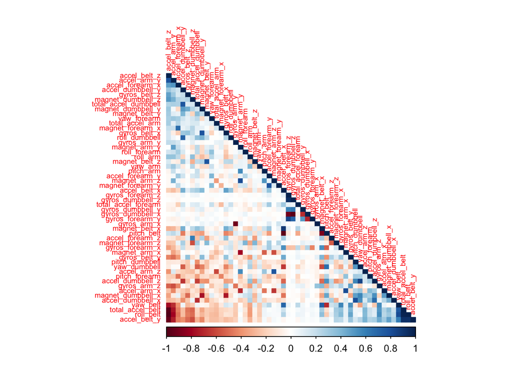

```r
correlation_matrix <- cor(dt_training[, -53])
corrplot(correlation_matrix,  order = "FPC", type = "lower", method = "color", tl.cex = 0.6)
```

## 3. Prediciton

## Model Building

For the building the model I use 70% of the training dataset and the remaining 30% to test the model.

```r
dt_training_partition  <- createDataPartition(dt_training$classe, p=0.7, list=FALSE)
dt_training_train <- dt_training[dt_training_partition, ]
dt_training_test  <- dt_training[-dt_training_partition, ]
```

Ensure reproducibility

```r
set.seed(8498)
```

I am going to use three models mentioned in the lecture from trees, random forest and boosting. For each model, I apply cross-validation (fitControl).

```r
fitControl <- trainControl(method='cv', number = 3)

model_rpart <- train(classe ~ ., data=dt_training_train, trControl=fitControl, method='rpart')
model_gbm <- train(classe ~ ., data=dt_training_train, trControl=fitControl, method='gbm', verbose = FALSE)
model_rf <- train(classe ~ ., data=dt_training_train, trControl=fitControl, method='rf')
```

Assessment

Out-of-sample error

```r
model_rpart$finalModel
```

```
## n= 13737
##
## node), split, n, loss, yval, (yprob)
##       * denotes terminal node
##
##  1) root 13737 9831 A (0.28 0.19 0.17 0.16 0.18)
##    2) roll_belt< 130.5 12588 8693 A (0.31 0.21 0.19 0.18 0.11)
##      4) pitch_forearm< -33.95 1103    8 A (0.99 0.0073 0 0 0) *
##      5) pitch_forearm>=-33.95 11485 8685 A (0.24 0.23 0.21 0.2 0.12)
##       10) magnet_dumbbell_y< 436.5 9686 6957 A (0.28 0.18 0.24 0.19 0.11)
##         20) roll_forearm< 123.5 6066 3626 A (0.4 0.18 0.19 0.17 0.061) *
##         21) roll_forearm>=123.5 3620 2430 C (0.08 0.17 0.33 0.24 0.18) *
##       11) magnet_dumbbell_y>=436.5 1799  890 B (0.039 0.51 0.038 0.22 0.2) *
##    3) roll_belt>=130.5 1149   11 E (0.0096 0 0 0 0.99) *
```

```r
model_gbm$finalModel
```

```
## A gradient boosted model with multinomial loss function.
## 150 iterations were performed.
## There were 52 predictors of which 52 had non-zero influence.
```

```r
model_rf$finalModel
```

```
##
## Call:
##  randomForest(x = x, y = y, mtry = param$mtry)
##                Type of random forest: classification
##                      Number of trees: 500
## No. of variables tried at each split: 27
##
##         OOB estimate of  error rate: 0.67%
## Confusion matrix:
##      A    B    C    D    E class.error
## A 3900    5    0    0    1 0.001536098
## B   17 2635    6    0    0 0.008653123
## C    0   14 2376    6    0 0.008347245
## D    0    2   24 2225    1 0.011989343
## E    1    1    6    8 2509 0.006336634
```

Random Forest has the highest accuracy.

Check the accuracy with the training data test set (30% not used for training)

```r
predRPART <- predict(model_rpart, newdata = dt_training_test)
```

Accuracy RPART

```r
confusionMatrixRPART <- confusionMatrix(predRPART, as.factor(dt_training_test$classe))
confusionMatrixRPART$overall[1]
```

```
##  Accuracy
## 0.5024639
```

```r
predGBM <- predict(model_gbm, newdata = dt_training_test)
```

Accuracy GBM

```r
confusionMatrixGBM <- confusionMatrix(predGBM, as.factor(dt_training_test$classe))
confusionMatrixGBM$overall[1]
```

```
##  Accuracy
## 0.9610875
```

```r
predRF <- predict(model_rf, newdata = dt_training_test)
```

Accuracy RF

```r
confusionMatrixRF <- confusionMatrix(predRF, as.factor(dt_training_test$classe))
confusionMatrixRF$overall[1]
```

```
##  Accuracy
## 0.9950722
```

## Verification

Let’s use Random Forest which has shown the highest accuracy.

```r
dt_testing <- read.csv(url("https://d396qusza40orc.cloudfront.net/predmachlearn/pml-testing.csv"), strip.white = TRUE)

predVerification <- predict(model_rf, dt_testing)
predVerification
```

```
##  [1] B A B A A E D B A A B C B A E E A B B B
## Levels: A B C D E
```

## 4. Conclusion

Random Forest is the best fit for the data available.